# Among U.S. children aged 0–17, is low birth weight associated with increased odds of an ever asthma diagnosis, after adjusting for child age, sex, race/ethnicity, household income, and secondhand smok

## Prevalence Difference % (95% CI)

```r
# Model 1: Unadjusted ===============================================
# predicted asthma probability, No vs Yes
pred_model1 <- predictions(model1,
                           newdata = datagrid(
                             birth_weight_low = c("No", "Yes")))

# Checks if the two predictions differ
hypotheses(pred_model1, hypothesis = "b2 = b1")
```

```
 Hypothesis Estimate Std. Error    z Pr(>|z|)   S   2.5 % 97.5 %
      b2=b1   0.0519     0.0449 1.16    0.248 2.0 -0.0361   0.14
```

```r
# Model 2: Age-adjusted =============================================
# same predictions, now controlling for age
pred_model2 <- predictions(model2,
                           newdata = datagrid(
                             birth_weight_low = c("No", "Yes")))

# Checks if the two predictions differ
hypotheses(pred_model2, hypothesis = "b2 = b1")
```

```
 Hypothesis Estimate Std. Error    z Pr(>|z|)   S  2.5 % 97.5 %
      b2=b1   0.0474     0.0456 1.04    0.299 1.7 -0.042  0.137
```

```r
# Model 3: Fully adjusted (multiple covariates) =====================
# same predictions, now controlling for *almost* everything
pred_model3 <- predictions(model3,
                           newdata = datagrid(
                             birth_weight_low = c("No", "Yes")))

# Checks if the two predictions differ
hypotheses(pred_model3, hypothesis = "b2 = b1")
```

```
 Hypothesis Estimate Std. Error    z Pr(>|z|)   S   2.5 % 97.5 %
      b2=b1   0.0147     0.0566 0.26    0.795 0.3 -0.0962  0.126
```

```r
# Event counts for the full sample
df |>
  group_by(birth_weight_low) |>
  summarise(n = n(),
            events = sum(asthma == "Yes", na.rm = TRUE),
            pct = round(100 * events / sum(!is.na(asthma)), 1))
```

```
# A tibble: 3 × 4
  birth_weight_low     n events   pct
  <fct>            <int>  <int> <dbl>
1 No               48256   4358   9.1
2 Yes               4679    661  14.3
3 <NA>              2227    190   8.7
```

```r
# Adjusted prevalence differences (probability scale), Low vs Normal
avg_comparisons(model1, variables = "birth_weight_low")     # unadjusted
```

```
 Estimate Std. Error    z Pr(>|z|)    S  2.5 % 97.5 %
   0.0519    0.00531 9.77   <0.001 72.5 0.0415 0.0623

Term: birth_weight_low
Type: response
Comparison: Yes - No
```

```r
avg_comparisons(model2, variables = "birth_weight_low")     # adjusted
```

```
 Estimate Std. Error   z Pr(>|z|)    S  2.5 % 97.5 %
    0.051     0.0052 9.8   <0.001 72.9 0.0408 0.0612

Term: birth_weight_low
Type: response
Comparison: Yes - No
```

```r
avg_comparisons(model3, variables = "birth_weight_low")
```

```
 Estimate Std. Error    z Pr(>|z|)   S   2.5 % 97.5 %
   0.0168    0.00524 3.22   0.0013 9.6 0.00658 0.0271

Term: birth_weight_low
Type: response
Comparison: Yes - No
```

*Interpretation*

On the absolute (probability) scale, low-birth-weight children had roughly 5 percentage points higher predicted probability of asthma than normal-birth-weight children in both the unadjusted and age-adjusted models (prevalence difference ≈ 5.1 to 5.2 percentage points, 95% CI roughly 4 to 6 percentage points, p < 0.001). This is consistent with the crude prevalences (14.3% versus 9.1%) and with the corresponding odds ratios, both scales point toward the same conclusion that low birth weight is associated with higher asthma risk.

After full adjustment in Model 3, the prevalence difference narrows to about 1.7 percentage points (95% CI: 0.7 to 2.7), mirroring the attenuation already seen in the odds ratio (1.67 to 1.21) and reflecting that much of the crude absolute difference is explained by the covariates added in that model. Reporting both the odds ratio and the prevalence difference is useful because the odds ratio captures the relative strength of the association while the prevalence difference conveys its absolute, population-level impact.

# Table 3. Adjusted Associations between Birth Weight Status and Ever Asthma Diagnosis, Stratified by Age Group*

| Age group | Birth weight status | Events, N (%) | Prevalence difference % (95% CI) | Odds ratio (95% CI) |
| --- | --- | --- | --- | --- |
| Toddler (0-2 years) | Normal birth weight | 193 (2.3%) | Reference | 1.00 |
|  | Low birth weight | 38 (5.3%) | 0.8 (−0.5 to 2.2) | 1.37 (0.86–2.14) |
| Preschool (3-5 years) | Normal birth weight | 671 (6.4%) | Reference | 1.00 |
|  | Low birth weight | 119 (11.3%) | 2.6 (0.5 to 4.6) | 1.44 (1.11–1.86) |
| Middle childhood (6-12 years) | Normal birth weight | 1527 (10.0%) | Reference | 1.00 |
|  | Low birth weight | 241 (15.9%) | 1.8 (−0.1 to 3.8) | 1.21 (1.00–1.45) |
| Teenager (13-17 years) | Normal birth weight | 1967 (14.3%) | Reference | 1.00 |
|  | Low birth weight | 263 (19.7%) | 1.1 (−1.1 to 3.4) | 1.09 (0.92–1.30) |

<sub>Adjusted results estimated using logistic regression, run separately within each age stratum, adjusted for sex, race/ethnicity, preterm birth, familial poverty ratio, education level of adults, insurance type, and household smoker status</sub>

*Table 3 Notes:*

*Only preschool (3-5) is significant on both scales (prevalence diff CI excludes 0, OR CI excludes 1). Middle childhood (6-12) is borderline on both (OR lower bound = 1.00, prevalence diff lower bound = −0.1). Toddlers and teens are non-significant. The overall pattern: the low-birth-weight/asthma association is strongest in early childhood and fades with age.*

## Age-Stratified Models (Table 3)

### Infants to Toddlers (0-2 years) Model

```r
# Toddlers (0-2 years)

# fit the asthma model for infants to toddlers
model_toddler <- glm(asthma ~ birth_weight_low + sex + race + born_early
                     + poverty + education + insurance_type + cigarettes,
                     data = filter(df, age_cats == "Infants/Toddlers (0-2)"),
                     family = binomial)

# pull the odds ratio + CI for low birth weight
tidy(model_toddler, exponentiate = TRUE, conf.int = TRUE) |>
  filter(str_detect(term, "birth_weight_low"))
```

```
# A tibble: 1 × 7
  term                estimate std.error statistic p.value conf.low conf.high
  <chr>                  <dbl>     <dbl>     <dbl>   <dbl>    <dbl>     <dbl>
1 birth_weight_lowYes     1.37     0.231      1.36   0.174    0.863      2.14
```

```r
# checks how many kids the model used
nobs(model_toddler)
```

```
[1] 8788
```

```r
# predicted asthma probability, No vs Yes
pred_toddler <- predictions(model_toddler,
                            newdata = datagrid(
                              birth_weight_low = c("No", "Yes")))

# check if the two predictions differ
hypotheses(pred_toddler, hypothesis = "b1 = b2")
```

```
 Hypothesis Estimate Std. Error       z Pr(>|z|)   S  2.5 % 97.5 %
      b1=b2 -0.00827      0.231 -0.0358    0.971 0.0 -0.461  0.445
```

**Interpretation**

*The birth weight association is not significant in this age group. OR = 1.37 (95% CI: 0.86–2.14, p = 0.17) as the CI crosses 1. The sample size is 8,788 toddlers. Among toddlers, low birth weight shows no statistically significant association with asthma on either scale. The OR points in the same direction as the overall analysis but is imprecise, likely because asthma is rarer and less established at this age (fewer cases to detect an effect).*

### Preschoolers (3-5 years) Model

```r
# Preschool (3-5 years)

# fit the asthma model for preschoolers
model_prek <- glm(asthma ~ birth_weight_low + sex + race + born_early +
                    poverty + education + insurance_type + cigarettes,
                  data = filter(df, age_cats == "Preschool (3-5)"),
                  family = binomial)

# pull the odds ratio + CI for low birth weight
tidy(model_prek, exponentiate = TRUE, conf.int = TRUE) |>
  filter(str_detect(term, "birth_weight_low"))
```

```
# A tibble: 1 × 7
  term                estimate std.error statistic p.value conf.low conf.high
  <chr>                  <dbl>     <dbl>     <dbl>   <dbl>    <dbl>     <dbl>
1 birth_weight_lowYes     1.44     0.132      2.75 0.00598     1.11      1.86
```

```r
# Checks how many kids did the model use
nobs(model_prek)
```

```
[1] 11115
```

```r
# Predicted asthma probability, No vs Yes
pred_prek <- predictions(model_prek,
                         newdata = datagrid(
                           birth_weight_low = c("No", "Yes")))

# Checks if the two predictions differ
hypotheses(pred_prek, hypothesis = "b1 = b2")
```

```
 Hypothesis Estimate Std. Error      z Pr(>|z|)   S  2.5 % 97.5 %
      b1=b2  -0.0281      0.132 -0.212    0.832 0.3 -0.287  0.231
```

**Interpretation**

### Middle Childhood (6-12 years) Model

```r
# Middle childhood (6-12)

# fit the asthma model for middle childhood
model_middle <- glm(asthma ~ birth_weight_low + sex + race + born_early +
                      poverty + education + insurance_type + cigarettes,
                    data = filter(df, age_cats == "Middle childhood (6-12)"),
                    family = binomial)

# pull the odds ratio + CI for low birth weight
tidy(model_middle, exponentiate = TRUE, conf.int = TRUE) |>
  filter(str_detect(term, "birth_weight_low"))
```

```
# A tibble: 1 × 7
  term                estimate std.error statistic p.value conf.low conf.high
  <chr>                  <dbl>     <dbl>     <dbl>   <dbl>    <dbl>     <dbl>
1 birth_weight_lowYes     1.21    0.0961      1.95  0.0510    0.998      1.45
```

```r
# checks how many kids did the model use
nobs(model_middle)
```

```
[1] 16280
```

```r
# Predicted asthma probability, No vs Yes
pred_middle <- predictions(model_middle,
                           newdata = datagrid(
                             birth_weight_low = c("No", "Yes")))

# # check if the two predictions differ
hypotheses(pred_middle, hypothesis = "b1 = b2")
```

```
 Hypothesis Estimate Std. Error      z Pr(>|z|)   S  2.5 % 97.5 %
      b1=b2  -0.0166     0.0961 -0.173    0.863 0.2 -0.205  0.172
```

**Interpretation**

*The birth weight association is borderline and just misses significance. OR = 1.21 (95% CI: 0.998–1.45, p = 0.051). The CI barely touches 1. This is the largest subsample with16,280 kids. Among middle-childhood kids, low birth weight shows a suggestive but not quite statistically significant association with asthma (p right at 0.05, CI’s lower bound essentially at 1). The effect size (OR 1.21) matches the overall fully-adjusted estimate, so it’s consistent in direction and magnitude, just short of the significance threshold in this subgroup.*

### Teenagers (13-17 years) Model

```r
# Teenagers (13-17)

# Fit the asthma model for teens
model_teens <- glm(asthma ~ birth_weight_low + sex + race + born_early +
                      poverty + education + insurance_type + cigarettes,
                    data = filter(df, age_cats == "Teenagers (13-17)"),
                    family = binomial)

# Pull the odds ratio + CI for low birth weight
tidy(model_teens, exponentiate = TRUE, conf.int = TRUE) |>
  filter(str_detect(term, "birth_weight_low"))
```

```
# A tibble: 1 × 7
  term                estimate std.error statistic p.value conf.low conf.high
  <chr>                  <dbl>     <dbl>     <dbl>   <dbl>    <dbl>     <dbl>
1 birth_weight_lowYes     1.09    0.0886      1.00   0.317    0.917      1.30
```

```r
# Checks how many teens the model used
nobs(model_teens)
```

```
[1] 14397
```

```r
# Predicted asthma probability, No vs Yes
pred_teens <- predictions(model_teens,
                           newdata = datagrid(
                             birth_weight_low = c("No", "Yes")))

# Checks if the two predictions differ
hypotheses(pred_teens, hypothesis = "b1 = b2")
```

```
 Hypothesis Estimate Std. Error      z Pr(>|z|)   S  2.5 % 97.5 %
      b1=b2  -0.0105     0.0886 -0.118    0.906 0.1 -0.184  0.163
```

**Interpretation**

*The birth weight association is not significant. OR = 1.09 (95% CI: 0.92–1.30, p = 0.32) (CI crosses 1). The sample size is14,397 teens. Among teenagers, low birth weight shows no significant association with asthma on either scale. This is the weakest effect of all age groups (OR closest to 1), suggesting any early birth-weight association has largely faded by adolescence.*

```r
# Information for filling out Table 3

# Gives the covariate-adjusted prevalence difference on the probability scale.
avg_comparisons(model_toddler, variables = "birth_weight_low")
```

```
 Estimate Std. Error    z Pr(>|z|)   S    2.5 % 97.5 %
  0.00849    0.00695 1.22    0.222 2.2 -0.00513 0.0221

Term: birth_weight_low
Type: response
Comparison: Yes - No
```

```r
avg_comparisons(model_prek,    variables = "birth_weight_low")
```

```
 Estimate Std. Error    z Pr(>|z|)   S   2.5 % 97.5 %
   0.0256     0.0105 2.45   0.0142 6.1 0.00516 0.0461

Term: birth_weight_low
Type: response
Comparison: Yes - No
```

```r
avg_comparisons(model_middle,  variables = "birth_weight_low")
```

```
 Estimate Std. Error    z Pr(>|z|)   S    2.5 % 97.5 %
   0.0182    0.00987 1.85   0.0648 3.9 -0.00112 0.0376

Term: birth_weight_low
Type: response
Comparison: Yes - No
```

```r
avg_comparisons(model_teens,   variables = "birth_weight_low")
```

```
 Estimate Std. Error     z Pr(>|z|)   S   2.5 % 97.5 %
   0.0112     0.0115 0.977    0.329 1.6 -0.0113 0.0337

Term: birth_weight_low
Type: response
Comparison: Yes - No
```

**Interpretation**

*These are the covariate-adjusted absolute differences (low vs normal birth weight) within each age stratum, and they populate the prevalence-difference column of Table 3. Only preschool (3–5) reaches significance (2.6 pp, 95% CI 0.5–4.6). Toddlers (0.8 pp), middle childhood (1.8 pp), and teenagers (1.1 pp) all have confidence intervals that cross zero. The pattern mirrors the odds ratios: the absolute effect of low birth weight on asthma risk is largest in early childhood and diminishes with age.*

# Results

## Staged regression models

We fit three logistic regression models in stages and report both the odds ratio and the prevalence difference for each. The prevalence differences were estimated as average marginal effects using `avg_comparisons()`.

## Age stratified models

We re-ran the fully adjusted model separately within each age group (Table 3), dropping age as a covariate inside each stratum. The association was statistically significant only among preschoolers ages 3 to 5 (OR 1.44, 95% CI 1.11 to 1.86; prevalence difference 2.6, 95% CI 0.5 to 4.6). Toddlers ages 0 to 2 had an odds ratio in the same direction (1.37) but a wide interval crossing the null (0.86 to 2.14). Middle childhood ages 6 to 12 was borderline, with a lower confidence bound at exactly 1.00. Teenagers ages 13 to 17 showed no significant association (OR 1.09, 95% CI 0.92 to 1.30).

# Conclusions

We found that low birth weight was associated with a higher prevalence of ever being diagnosed with asthma among U.S. children. The crude association was fairly strong (OR 1.67), and while it weakened substantially after adjusting for demographic and socioeconomic factors, it did not go away (adjusted OR 1.21, adjusted prevalence difference of about 1.7 percentage points). This tells us two things at once. First, part of what looks like a birth weight effect is really being carried by other correlated factors like preterm birth and socioeconomic status. Second, even after accounting for those factors, low birth weight still carries its own association with asthma.

The age stratified results add some detail to this. The association is not uniform across childhood. It shows up most clearly in preschool aged children and essentially disappears by adolescence. One reasonable interpretation is that low birth weight is linked to earlier onset asthma, and that by the teenage years other pathways to an asthma diagnosis have caught up, diluting the birth weight signal. We cannot confirm that from this data, but it fits the pattern we see.

From a public health standpoint, the odds ratio and the prevalence difference tell complementary stories. The adjusted odds ratio of 1.21 is modest, so low birth weight is not one of the strongest predictors of asthma we looked at. But because childhood asthma is common, even a modest association translates into a meaningful number of additional cases at the population level, which is what the prevalence difference is capturing.

# Limitations

There are several limitations worth being upfront about.

First, and most importantly, this is a cross sectional study. The NSCH measures children at one point in time, so we are capturing the prevalence of an existing asthma diagnosis, not the incidence of new cases. This is why we reported prevalence differences rather than risk differences. It also means we cannot establish temporality or claim causation, so everything here should be read as an association, not a proven effect.

Second, the exposure, outcome, and most covariates are parent reported rather than taken from medical records, which opens the door to recall bias and misclassification. A parent may not report a child’s birth weight accurately, and “ever diagnosed with asthma” depends on the child having had access to care in the first place.

Third, we used complete case analysis and let each model drop only the cases missing the variables it used. This keeps the simpler models from shrinking unnecessarily, but it means Model 3 is fit on a smaller sample than Models 1 and 2, so the attenuation across models is not entirely clean. We documented the missingness rather than imputing it.

Fourth, there is almost certainly residual confounding. Variables like environmental exposures, family history of asthma, and maternal health during pregnancy are not in this dataset, and any of them could explain part of the association we are attributing to birth weight. Relatedly, preterm birth is included as a covariate even though it is often the cause of low birth weight rather than an independent confounder. Adjusting for a variable on the exposure’s own causal pathway can remove part of the effect we are trying to estimate, so the drop from an odds ratio of 1.67 to 1.21 likely reflects some over-adjustment alongside genuine confounding. The fully adjusted estimate may therefore understate the total association between low birth weight and asthma.

Fifth, we excluded BMI because it is only collected for children ages 6 to 17 and cannot be placed in the right time order relative to birth weight. That was the right call for temporality, but it kept us from exploring a variable that plausibly sits on the pathway.

Finally, the NSCH uses a complex survey sampling design. A fully rigorous analysis would incorporate the survey weights, so our confidence intervals in particular should be read with some caution.

Despite these limitations, the pattern is consistent and lines up with prior literature: low birth weight is associated with higher asthma prevalence in children, the association is partly but not fully explained by other factors, and it is most apparent in early childhood.

# Appendix

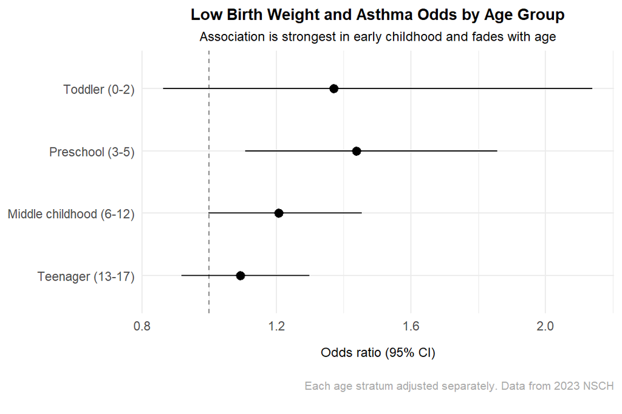

```r
# Combine the four age-stratified models into one table of odds ratios with 95% CIs.
strat <- bind_rows(
  tidy(model_toddler, exponentiate = TRUE, conf.int = TRUE) |> mutate(age_group = "Toddler (0-2)"),
  tidy(model_prek,    exponentiate = TRUE, conf.int = TRUE) |> mutate(age_group = "Preschool (3-5)"),
  tidy(model_middle,  exponentiate = TRUE, conf.int = TRUE) |> mutate(age_group = "Middle childhood (6-12)"),
  tidy(model_teens,   exponentiate = TRUE, conf.int = TRUE) |> mutate(age_group = "Teenager (13-17)")
) |>
  filter(str_detect(term, "birth_weight_low")) |>
  mutate(age_group = factor(age_group,
                            levels = c("Teenager (13-17)", "Middle childhood (6-12)",
                                       "Preschool (3-5)", "Toddler (0-2)")))

# Plot odds ratios with confidence intervals by age group.
ggplot(strat, aes(x = estimate, y = age_group)) +
  geom_vline(xintercept = 1, linetype = "dashed", color = "gray50") +
  geom_pointrange(aes(xmin = conf.low, xmax = conf.high)) +
  labs(title = "Low Birth Weight and Asthma Odds by Age Group",
       subtitle = "Association is strongest in early childhood and fades with age",
       x = "Odds ratio (95% CI)", y = NULL,
       caption = "Each age stratum adjusted separately. Data from 2023 NSCH") +
  theme_minimal() +
  theme(
    plot.title = element_text(size = 11,
                              face = "bold",
                              hjust = 0.5),
    plot.subtitle = element_text(size = 9, hjust = 0.5),
    axis.title.x = element_text(margin = margin(t = 10), size = 9),
    axis.title.y = element_text(margin = margin(r = 10), size = 9),
    plot.caption = element_text(
      size = 8,
      color = "darkgray",
      margin = margin(t = 15, b = 10, unit = "pt")
    ))
```